# Modelando la probabilidad de incumplimiento

```
Variable: annual_inc
[1] "0"
[2] "1"
[3] "2"
[4] "3_4_5_6_7_8_9_10_11_12_13_14_15_16_17_18_19_20_24_25_27_28_31_32_33"
```

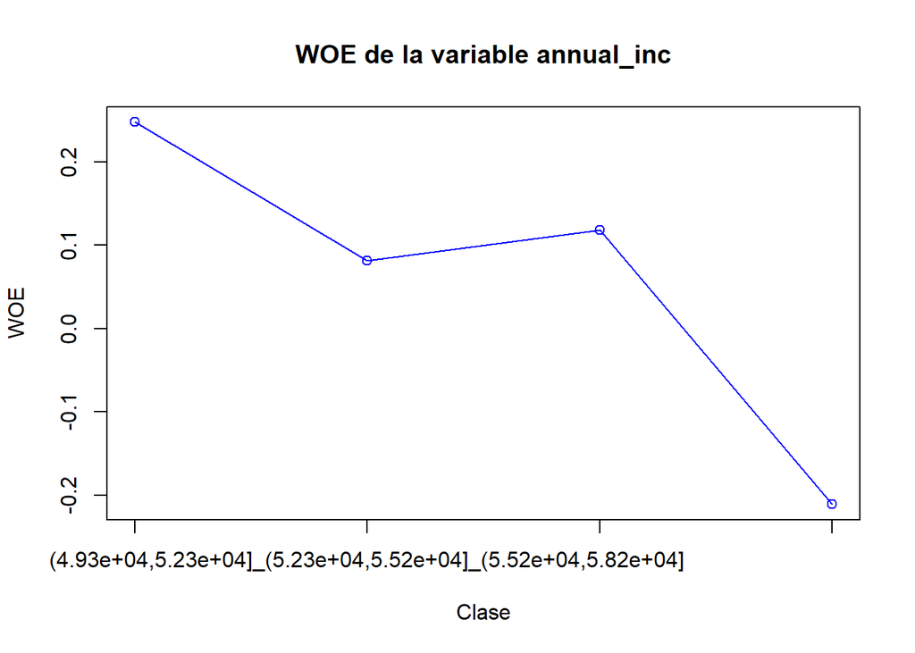

```
Variable: int_rate
[1] "0"
[2] "1"
[3] "2"
[4] "3_4_5_6_7_8_9_10_11_12_13_14_15_16_17_18_19_20_24_25_27_28_31_32_33"
```

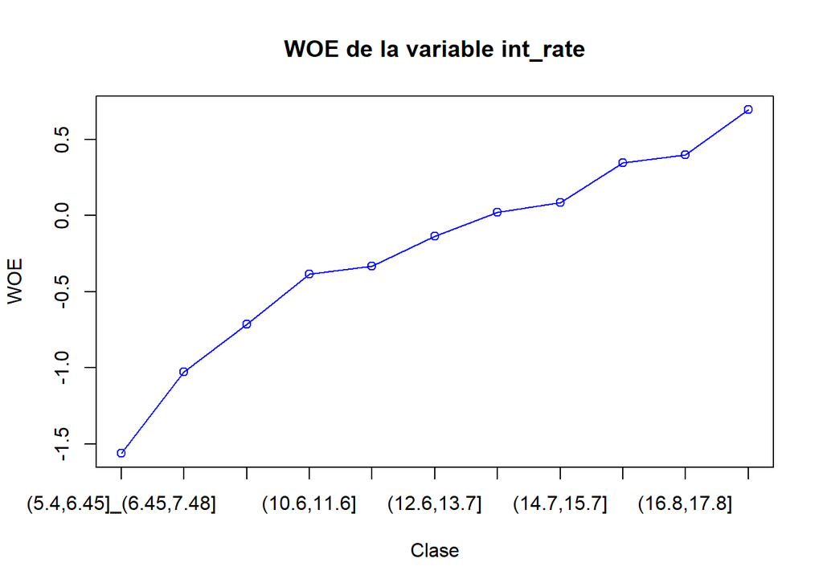

```
Variable: mths_since_last_delinq
[1] "0"
[2] "1"
[3] "2"
[4] "3_4_5_6_7_8_9_10_11_12_13_14_15_16_17_18_19_20_24_25_27_28_31_32_33"
```

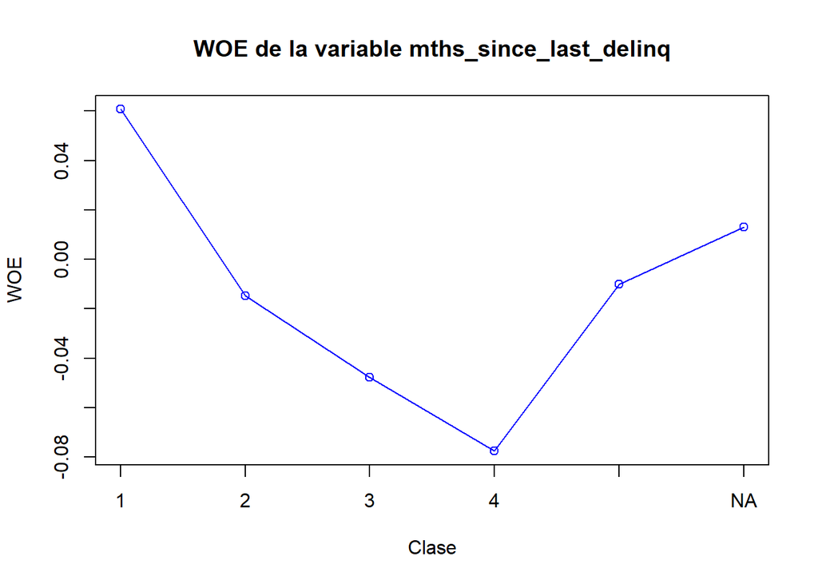

```
Variable: mths_since_last_record
[1] "0"
[2] "1"
[3] "2"
[4] "3_4_5_6_7_8_9_10_11_12_13_14_15_16_17_18_19_20_24_25_27_28_31_32_33"
```

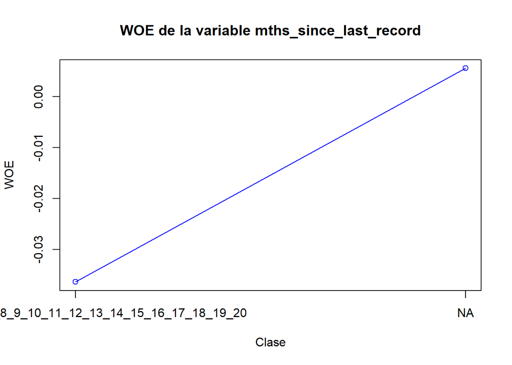

```r
coarse_classing_results_numeric_var <- list()
i = 1
for(var_ in numeric_var ){
  coarse_classing_results_numeric_var[[var_]]<-coarse_classing(train_numeric_var[[var_,drop=FALSE]] , "y", numeric_var[i])
  i = i + 1
}

numeric_label <- list()
# Imprimir los resultados
for (i in 1:length(numeric_var)) {
  cat("Variable:", names(coarse_classing_results_numeric_var)[i], "\n")
  df_aux <- coarse_classing_results_numeric_var[[i]][[1]]
  print( df$Categoria)
  numeric_label[[names(coarse_classing_results_numeric_var)[i]]] <- df_aux$Categoria
  plot_woe(df_aux,
           var_name = names(coarse_classing_results_numeric_var)[i])
  cat("\n")
}
```

```r
coarse_classing_results_numeric_var
```

```
$annual_inc
$annual_inc$annual_inc
                                                                                                                                                                                                                                                                                                            …
1                                                                                                                                                                                                                                                                                            (1.75e+03,4.86e…
2                                                                                                                                                                                                                                                                                                           …
3                                                                                                                                                                                                                                                                                                           …
4 (6.11e+04,6.41e+04]_(6.41e+04,6.71e+04]_(6.71e+04,7e+04]_(7e+04,7.3e+04]_(7.3e+04,7.59e+04]_(7.59e+04,7.89e+04]_(7.89e+04,8.19e+04]_(8.19e+04,8.48e+04]_(8.48e+04,8.78e+04]_(8.78e+04,9.08e+04]_(9.08e+04,9.37e+04]_(9.37e+04,9.67e+04]_(9.67e+04,9.96e+04]_(9.96e+04,1.03e+05]_(1.03e+05,1.06e+05]_(1.06e…
          WOE Total_buenos Total_malos  Total Total_porcentaje
1  0.24775606        15259       97345 112604       0.30186798
2  0.08136443         5823       43873  49696       0.13322467
3  0.11824425         2301       16709  19010       0.05096187
4 -0.21102155        17282      174432 191714       0.51394548


$int_rate
$int_rate$int_rate
                                                                             Categoria
1                                                               (5.4,6.45]_(6.45,7.48]
2                                                                          (7.48,8.52]
3                                                              (8.52,9.55]_(9.55,10.6]
4                                                                          (10.6,11.6]
5                                                                          (11.6,12.6]
6                                                                          (12.6,13.7]
7                                                                          (13.7,14.7]
8                                                                          (14.7,15.7]
9                                                                          (15.7,16.8]
10                                                                         (16.8,17.8]
11 (17.8,18.8]_(18.8,19.9]_(19.9,20.9]_(20.9,21.9]_(21.9,23]_(23,24]_(24,25]_(25,26.1]
           WOE Total_buenos Total_malos Total Total_porcentaje
1  -1.56294552          553       21572 22125       0.05931254
2  -1.02615090         1141       26021 27162       0.07281569
3  -0.71361193         2153       35921 38074       0.10206850
4  -0.38590173         2078       24982 27060       0.07254225
5  -0.33141730         2904       33061 35965       0.09641471
6  -0.13392415         3842       35901 39743       0.10654274
7   0.02081472         4224       33812 38036       0.10196663
8   0.08528753         3751       28151 31902       0.08552265
9   0.34699960         3378       19514 22892       0.06136871
10  0.39777271         3916       21502 25418       0.06814039
11  0.69467391        12725       51922 64647       0.17330520
```

[output cut: 13 more lines]

```
2       25873  28992       0.07772154
3       22625  25264       0.06772755
4       20456  22772       0.06104701
5       64566  72386       0.19405186
6      178195 200282       0.53691451


$mths_since_last_record
$mths_since_last_record$mths_since_last_record
                                           Categoria          WOE Total_buenos
1 1_2_3_4_5_6_7_8_9_10_11_12_13_14_15_16_17_18_19_20 -0.036313398         5293
2                                                 NA  0.005549103        35372
  Total_malos  Total Total_porcentaje
1       44860  50153        0.1344498
2      287499 322871        0.8655502
```

##### Creación de variables dummy

```r
#9- Income
d_inc_1=ifelse(datos$annual_inc<=as.numeric(4.93e+04),1,0)
d_inc_2=ifelse(datos$annual_inc>as.numeric(4.93e+0) & datos$annual_inc<=as.numeric(5.82e+04),1,0)
d_inc_3=ifelse(datos$annual_inc>as.numeric(5.82e+04) & datos$annual_inc<=as.numeric(6.11e+04),1,0)
d_inc_4=ifelse(datos$annual_inc>as.numeric(6.11e+04) & datos$annual_inc<=150000,1,0)
d_inc_5=ifelse(datos$annual_inc>150000,1,0)

df9<-d_int<-data.frame(d_inc_1,d_inc_2,d_inc_3, d_inc_4, d_inc_5)


#10- Int_rate
d_int_1=ifelse(datos$int_rate<=7.48,1,0)
d_int_2=ifelse(datos$int_rate >7.48 & datos$int_rate<=8.52 ,1,0)
d_int_3=ifelse(datos$int_rate>8.52 & datos$int_rate<=9.55,1,0)
d_int_4=ifelse(datos$int_rate>9.55 & datos$int_rate<=10.6,1,0)
d_int_5=ifelse(datos$int_rate>10.6 & datos$int_rate<=11.6,1,0)
d_int_6=ifelse(datos$int_rate>11.6 & datos$int_rate<=12.6,1,0)
d_int_7=ifelse(datos$int_rate>12.6 & datos$int_rate<=13.7,1,0)
d_int_8=ifelse(datos$int_rate>13.7 & datos$int_rate<=14.7,1,0)
d_int_9=ifelse(datos$int_rate>14.7 & datos$int_rate<=15.7,1,0)
d_int_10=ifelse(datos$int_rate>15.7 & datos$int_rate<=16.8,1,0)
d_int_11=ifelse(datos$int_rate>16.8,1,0)

df10<-data.frame(d_int_1,d_int_2,d_int_3, d_int_4, d_int_5, d_int_6,
                  d_int_7,d_int_8,d_int_9,d_int_10,d_int_11)


#11- mths_since_last_delinq

d_delinq_1=ifelse(is.na(datos$mths_since_last_delinq),1,0)
d_delinq_2=ifelse(!is.na(datos$mths_since_last_delinq) &
                                    datos$mths_since_last_delinq == 1,1,0)
d_delinq_3=ifelse(!is.na(datos$mths_since_last_delinq) &
                                    datos$mths_since_last_delinq == 2,1,0)
d_delinq_4=ifelse(!is.na(datos$mths_since_last_delinq) &
                                    datos$mths_since_last_delinq == 3,1,0)
d_delinq_5=ifelse(!is.na(datos$mths_since_last_delinq) &
                                    datos$mths_since_last_delinq == 4,1,0)
d_delinq_6=ifelse(!is.na(datos$mths_since_last_delinq) &
                                    datos$mths_since_last_delinq > 4,1,0)

df11<-data.frame(d_delinq_1,d_delinq_2,d_delinq_3,d_delinq_4,d_delinq_5,d_delinq_6)




#12- mths_since_last_record

d_record_1=ifelse(is.na(datos$mths_since_last_record),1,0)
d_record_2=ifelse(!is.na(datos$mths_since_last_record),1,0)

df12<-data.frame(d_record_1,d_record_2)
```

### Creación del modelo

```r
d_bueno_malo=datos$y

# Base de datos con las variables dummy
dummy<-cbind(datos$member_id,d_bueno_malo,df1,df2,df3,df4,df5,df6,df7,df8,df8_1,df9, df10,df11,df12)

#write.csv(dummy,"base_dummy.csv")

# Base de registros train con las variables dummy
dum_train=dummy[which(datos$member_id%in%train$member_id==TRUE),]
dum_train = dum_train[,-1]
# Base de registros train con las variables dummy
dum_test=dummy[which(datos$member_id%in%test$member_id==TRUE),]
dum_test = dum_test[,-1]
#write.csv(dummy_train,"dummy_train.csv")
dummy$d_bueno_malo <- as.numeric(dummy$d_bueno_malo)
dum_train$d_bueno_malo <- as.numeric(dum_train$d_bueno_malo)
dum_test$d_bueno_malo <- as.numeric(dum_test$d_bueno_malo)
```

Proceso de creación del modelo de regresión logística

Para cada cada variable, no se considera la variable dummy de menor WOE, con el fin de evitar colinearidad.

```r
dum_train_m<-subset(dum_train,select = -c(datos$member_id,d_grade_1,d_home_3,d_addr_state_2,d_ver_3,d_pur_4,d_list_1,d_term_2,d_emp_5,d_inq_1,d_int_1,d_inc_5,d_delinq_5,d_record_1))
names(dum_train_m)
```

```
 [1] "d_bueno_malo"   "d_grade_2"      "d_grade_3"      "d_grade_4"
 [5] "d_grade_5"      "d_home_1"       "d_home_2"       "d_addr_state_1"
 [9] "d_ver_1"        "d_ver_2"        "d_pur_1"        "d_pur_2"
[13] "d_pur_3"        "d_list_2"       "d_term_1"       "d_emp_1"
[17] "d_emp_2"        "d_emp_3"        "d_emp_4"        "d_inq_2"
[21] "d_inq_3"        "d_inq_4"        "d_inc_1"        "d_inc_2"
[25] "d_inc_3"        "d_inc_4"        "d_int_2"        "d_int_3"
[29] "d_int_4"        "d_int_5"        "d_int_6"        "d_int_7"
[33] "d_int_8"        "d_int_9"        "d_int_10"       "d_int_11"
[37] "d_delinq_1"     "d_delinq_2"     "d_delinq_3"     "d_delinq_4"
[41] "d_delinq_6"     "d_record_2"
```

```r
#Creación del model con todas las variables predictoras posibles:
model_1=glm(d_bueno_malo~.,family = binomial(link ="logit"),data=dum_train_m)
summary(model_1)
```

```
Call:
glm(formula = d_bueno_malo ~ ., family = binomial(link = "logit"),
    data = dum_train_m)

Coefficients:
               Estimate Std. Error z value Pr(>|z|)
(Intercept)     3.81071    0.07778  48.993  < 2e-16 ***
d_grade_2       0.52840    0.07365   7.174 7.27e-13 ***
d_grade_3       0.62906    0.07849   8.014 1.11e-15 ***
d_grade_4       0.64351    0.08166   7.880 3.28e-15 ***
d_grade_5       0.35263    0.08298   4.249 2.14e-05 ***
d_home_1       -0.15187    0.01210 -12.553  < 2e-16 ***
d_home_2       -0.00861    0.01999  -0.431 0.666612
d_addr_state_1 -0.12994    0.01111 -11.698  < 2e-16 ***
d_ver_1         0.10967    0.01419   7.731 1.07e-14 ***
d_ver_2         0.11035    0.01298   8.504  < 2e-16 ***
d_pur_1        -0.23600    0.01989 -11.868  < 2e-16 ***
d_pur_2        -0.11182    0.01418  -7.888 3.08e-15 ***
d_pur_3        -0.08299    0.02380  -3.487 0.000488 ***
d_list_2        0.29236    0.01197  24.425  < 2e-16 ***
d_term_1        0.07105    0.01365   5.206 1.93e-07 ***
d_emp_1        -0.13187    0.01804  -7.309 2.70e-13 ***
d_emp_2        -0.04422    0.01433  -3.085 0.002037 **
d_emp_3        -0.10250    0.01806  -5.677 1.37e-08 ***
d_emp_4        -0.07097    0.01730  -4.103 4.09e-05 ***
d_inq_2        -0.12533    0.01291  -9.711  < 2e-16 ***
d_inq_3        -0.25951    0.01627 -15.946  < 2e-16 ***
d_inq_4        -0.43563    0.01847 -23.589  < 2e-16 ***
d_inc_1        -0.13810    0.01699  -8.127 4.40e-16 ***
d_inc_2        -0.50203    0.03411 -14.716  < 2e-16 ***
d_inc_3        -0.55952    0.03840 -14.572  < 2e-16 ***
d_inc_4        -0.26755    0.03192  -8.383  < 2e-16 ***
d_int_2        -0.51516    0.05275  -9.765  < 2e-16 ***
d_int_3        -0.81896    0.05966 -13.728  < 2e-16 ***
d_int_4        -1.45361    0.08885 -16.361  < 2e-16 ***
d_int_5        -1.60071    0.08832 -18.123  < 2e-16 ***
d_int_6        -1.67260    0.08746 -19.124  < 2e-16 ***
d_int_7        -1.90983    0.08802 -21.697  < 2e-16 ***
d_int_8        -2.06895    0.09019 -22.941  < 2e-16 ***
d_int_9        -2.13751    0.09131 -23.410  < 2e-16 ***
d_int_10       -2.34409    0.09181 -25.531  < 2e-16 ***
d_int_11       -2.47823    0.09254 -26.781  < 2e-16 ***
d_delinq_1      0.25138    0.05442   4.619 3.85e-06 ***
d_delinq_2      0.38373    0.11105   3.456 0.000549 ***
d_delinq_3      0.29201    0.09893   2.952 0.003160 **
d_delinq_4      0.22899    0.09391   2.439 0.014747 *
d_delinq_6      0.35758    0.05445   6.567 5.12e-11 ***
d_record_2      0.16029    0.01606   9.983  < 2e-16 ***
---
Signif. codes:  0 '***' 0.001 '**' 0.01 '*' 0.05 '.' 0.1 ' ' 1

(Dispersion parameter for binomial family taken to be 1)

    Null deviance: 256976  on 373023  degrees of freedom
Residual deviance: 242215  on 372982  degrees of freedom
AIC: 242299

Number of Fisher Scoring iterations: 6
```

Ajuste sin la variable Home:

```r
# Creación del modelo con variables significativas
model_2=glm(d_bueno_malo~.,family = binomial(link ="logit"),
            data= dum_train_m[, !colnames(dum_train_m) %in% c("d_home_1", "d_home_2")])

summary(model_2)
```

```
Call:
glm(formula = d_bueno_malo ~ ., family = binomial(link = "logit"),
    data = dum_train_m[, !colnames(dum_train_m) %in% c("d_home_1",
        "d_home_2")])

Coefficients:
               Estimate Std. Error z value Pr(>|z|)
(Intercept)     3.83271    0.07775  49.292  < 2e-16 ***
d_grade_2       0.52138    0.07367   7.077 1.47e-12 ***
d_grade_3       0.61639    0.07851   7.852 4.11e-15 ***
d_grade_4       0.62485    0.08167   7.651 2.00e-14 ***
d_grade_5       0.32670    0.08297   3.937 8.24e-05 ***
d_addr_state_1 -0.13463    0.01110 -12.134  < 2e-16 ***
d_ver_1         0.10131    0.01416   7.155 8.38e-13 ***
d_ver_2         0.10163    0.01295   7.849 4.19e-15 ***
d_pur_1        -0.24190    0.01988 -12.170  < 2e-16 ***
d_pur_2        -0.11022    0.01417  -7.778 7.39e-15 ***
d_pur_3        -0.04937    0.02365  -2.088 0.036839 *
d_list_2        0.29430    0.01197  24.596  < 2e-16 ***
d_term_1        0.05038    0.01353   3.724 0.000196 ***
d_emp_1        -0.15400    0.01795  -8.580  < 2e-16 ***
d_emp_2        -0.07056    0.01418  -4.976 6.51e-07 ***
d_emp_3        -0.11886    0.01800  -6.602 4.06e-11 ***
d_emp_4        -0.08133    0.01727  -4.709 2.49e-06 ***
d_inq_2        -0.11966    0.01289  -9.280  < 2e-16 ***
d_inq_3        -0.24971    0.01625 -15.368  < 2e-16 ***
d_inq_4        -0.42058    0.01842 -22.833  < 2e-16 ***
d_inc_1        -0.14990    0.01694  -8.847  < 2e-16 ***
d_inc_2        -0.53031    0.03403 -15.586  < 2e-16 ***
d_inc_3        -0.58390    0.03833 -15.232  < 2e-16 ***
d_inc_4        -0.28184    0.03189  -8.837  < 2e-16 ***
d_int_2        -0.52365    0.05274  -9.928  < 2e-16 ***
d_int_3        -0.82665    0.05965 -13.859  < 2e-16 ***
d_int_4        -1.45970    0.08887 -16.426  < 2e-16 ***
d_int_5        -1.60857    0.08834 -18.209  < 2e-16 ***
d_int_6        -1.68523    0.08748 -19.265  < 2e-16 ***
d_int_7        -1.92174    0.08804 -21.828  < 2e-16 ***
d_int_8        -2.08086    0.09021 -23.068  < 2e-16 ***
d_int_9        -2.14929    0.09132 -23.535  < 2e-16 ***
d_int_10       -2.35629    0.09183 -25.659  < 2e-16 ***
d_int_11       -2.49046    0.09256 -26.907  < 2e-16 ***
d_delinq_1      0.23497    0.05439   4.320 1.56e-05 ***
d_delinq_2      0.39131    0.11101   3.525 0.000424 ***
d_delinq_3      0.29968    0.09891   3.030 0.002447 **
d_delinq_4      0.23791    0.09389   2.534 0.011278 *
d_delinq_6      0.34862    0.05443   6.405 1.51e-10 ***
d_record_2      0.16341    0.01605  10.181  < 2e-16 ***
---
Signif. codes:  0 '***' 0.001 '**' 0.01 '*' 0.05 '.' 0.1 ' ' 1

(Dispersion parameter for binomial family taken to be 1)

    Null deviance: 256976  on 373023  degrees of freedom
Residual deviance: 242386  on 372984  degrees of freedom
AIC: 242466

Number of Fisher Scoring iterations: 6
```

Se escoge el primer modelo por tener el menor AIC.

### Comprobación del modelo

```r
#Creación de una subbase de la matriz dummy test con las variables significativas

dum_test_signif<-subset(dum_test,select = -c(datos$member_id,d_grade_1,d_home_3,d_addr_state_2,d_ver_3,d_pur_4,d_list_1,d_term_2,d_emp_5,d_inq_1,d_int_1,d_inc_5,d_delinq_5,d_record_1))

# Predicción de probabilidades para la base test:
predicciones<-predict(model_1,newdata=dum_test_signif,type="response")
dum_test_signif$predicciones=predicciones #Creando la columna de probabilidades
```

#### Realización de la curva ROC

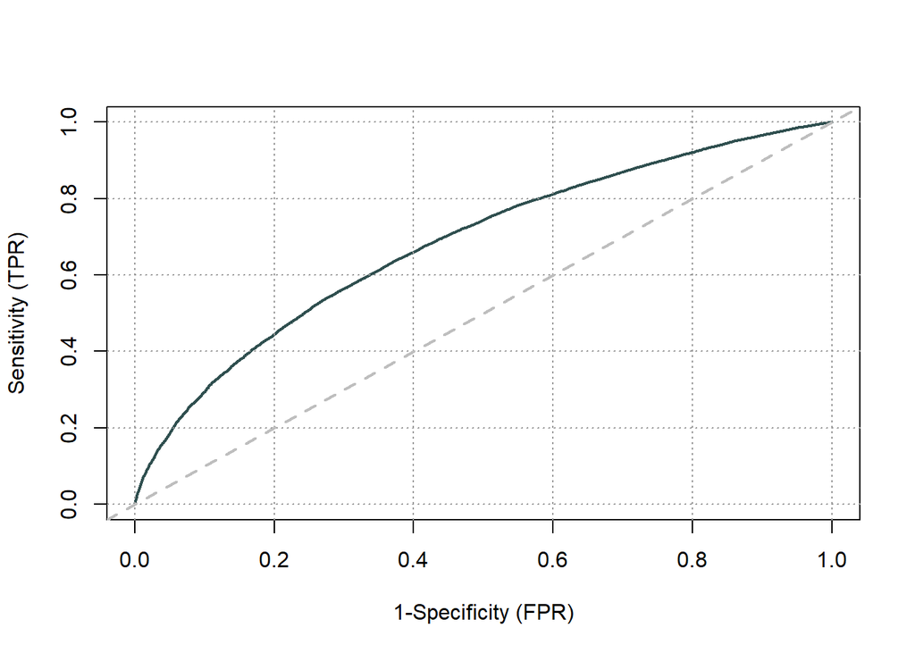

```r
##### Realizaci?n de la curva ROC
library(ROCit)
curva_roc=(rocit(dum_test_signif$predicciones,dum_test_signif$d_bueno_malo))
plot(curva_roc,YIndex=FALSE,legend=FALSE)
```

```r
summary(curva_roc)
```

```
 Method used: empirical
 Number of positive(s): 82954
 Number of negative(s): 10303
 Area under curve: 0.6827
```

```r
names(curva_roc)
```

```
[1] "method"    "pos_count" "neg_count" "pos_D"     "neg_D"     "AUC"
[7] "Cutoff"    "TPR"       "FPR"
```

```r
print(auc<-curva_roc$AUC)
```

```
[1] 0.6826672
```

Índice de Youden:

```r
tabla=data.frame(curva_roc$Cutoff,curva_roc$TPR,curva_roc$FPR)
tabla$esp=1-curva_roc$FPR
tabla$youden_index=tabla$curva_roc.TPR+ tabla$esp-1
print(optimal_point<-tabla[which(tabla$youden_index==max(tabla$youden_index)),1])
```

```
[1] 0.9007874
```

Coeficiente de Gini:

```r
#coeficiente de Gini
print(Gini<-2*auc-1)
```

```
[1] 0.3653344
```

#### Densidades

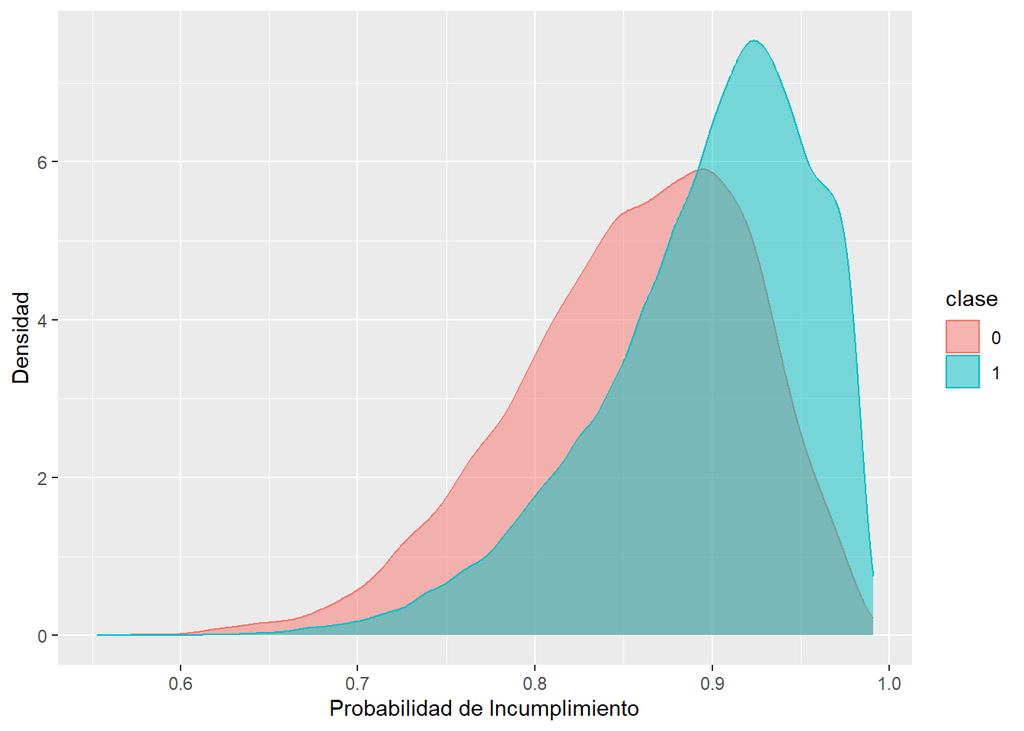

```r
pred=subset(dum_test_signif, select=c(d_bueno_malo,predicciones))
pred$clase=as.factor(pred$d_bueno_malo)
ggplot(pred, aes(predicciones, col=clase, fill=clase)) + geom_density(alpha=.5)+
labs(x = "Probabilidad de Incumplimiento", y = "Densidad")
```

#### Grafico de kolmogorov-smirnov

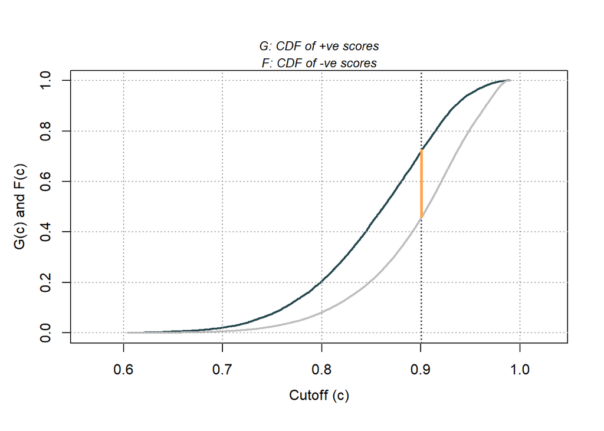

```r
ks=ksplot(curva_roc,legend=FALSE)
```

```r
estadistico_ks=ks$`KS stat`
```

Región de rechazo:

```r
nt_good <-sum(dum_test$d_bueno_malo)
nt_bad <-length(dum_test$d_bueno_malo)-sum(dum_test$d_bueno_malo)
1.36*sqrt((nt_good +nt_bad )/(nt_bad *nt_good))
```

```
[1] 0.01420624
```

##### Realización de la curva CAP

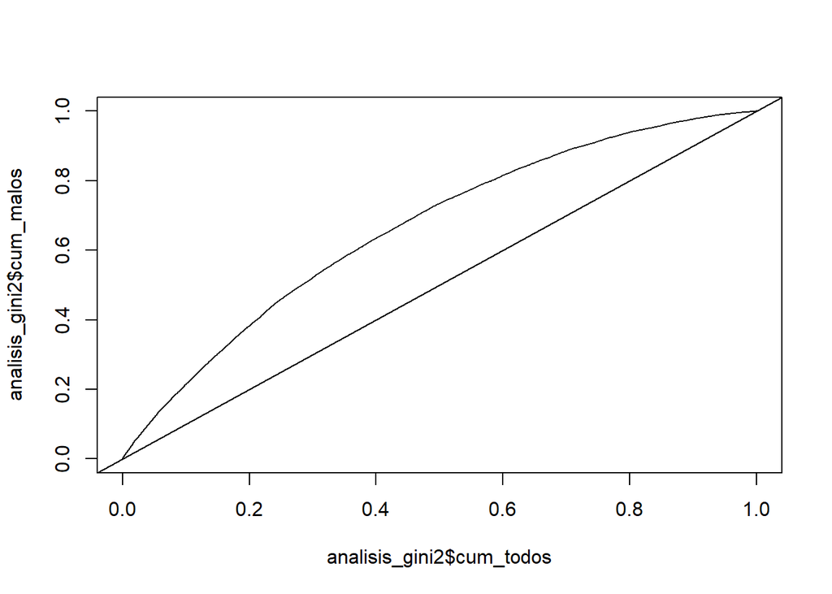

```r
analisis_gini=subset(dum_test_signif, select=c(d_bueno_malo,predicciones))
analisis_gini2=analisis_gini[order(analisis_gini$predicciones),]
analisis_gini2$cum_todos=seq(1,dim(analisis_gini2)[1])/dim(analisis_gini2)[1]
analisis_gini2$malos1buenos0=ifelse(analisis_gini2$d_bueno_malo==1,0,1)
analisis_gini2$cum_malos=cumsum(analisis_gini2$malos1buenos0)/sum(analisis_gini2$malos1buenos0)
plot(analisis_gini2$cum_todos,analisis_gini2$cum_malos,type="l")
abline(0,1)
```

```r
analisis_gini2$cum_malostotales=1
analisis_gini2$cum_malostotales[1:sum(analisis_gini2$malos1buenos0)]=seq(1,sum(analisis_gini2$malos1buenos0))/sum(analisis_gini2$malos1buenos0)
names(analisis_gini2)
```

```
[1] "d_bueno_malo"     "predicciones"     "cum_todos"        "malos1buenos0"
[5] "cum_malos"        "cum_malostotales"
```

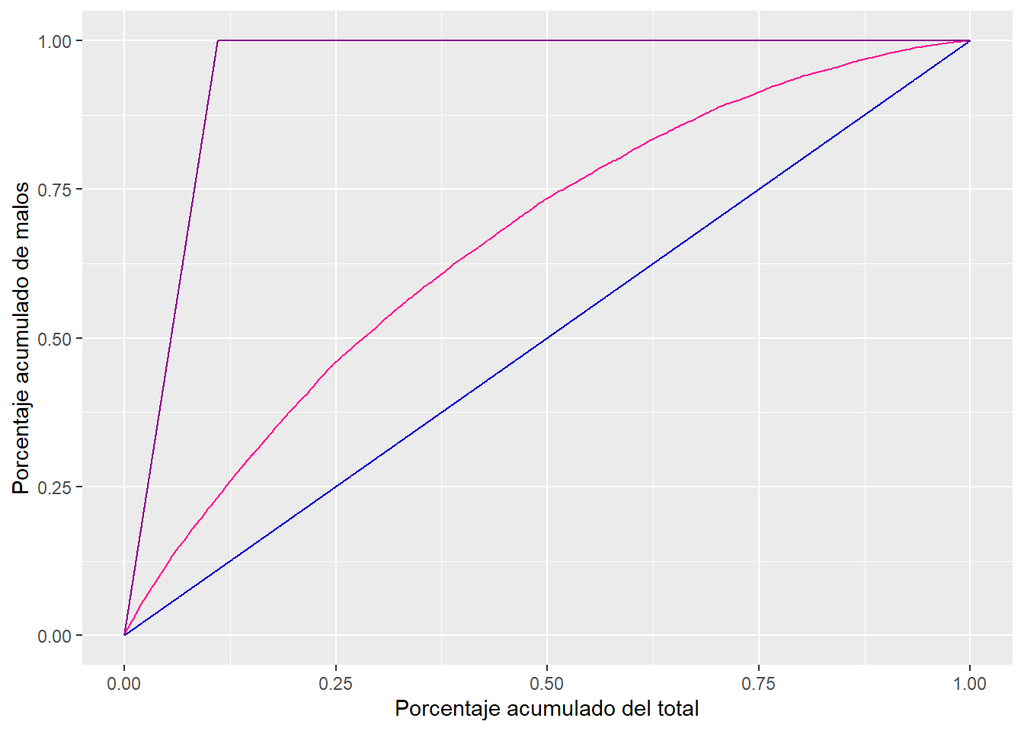

```r
library(ggplot2) #Librer?a para graficar
ggplot(analisis_gini2)+ geom_line(aes(x=cum_todos,y=cum_todos),col="blue3")+
  geom_line(aes(x=cum_todos,y=cum_malos),col="deeppink")+
  geom_line(aes(x=cum_todos,y=cum_malostotales),col="darkmagenta")+
  labs(x="Porcentaje acumulado del total",y="Porcentaje acumulado de malos")
```

#### Scores

Estableciendo el mínimo y máximo score:

```r
min_score=30
max_score=850
```

Proceso para calcular la suma de los mínimos coeficientes de cada variable y la suma de los máximos coeficientes:

```r
coef=data.frame(c("Intercepto",substr(names(dum_test_signif[,2:42]),3,6)),model_1$coefficients)
names(coef)=c("Variable","Coeficientes")
var_ref_name <- c("d_grade_1","d_home_3","d_addr_state_2","d_ver_3","d_pur_4","d_list_1","d_term_2","d_emp_5","d_inq_1","d_int_1","d_inc_5","d_delinq_5","d_record_1")
var_ref=substr(var_ref_name,3,6)
coef=rbind(coef,data.frame("Variable"=var_ref,"Coeficientes"=rep(0,length(var_ref))))
library(plyr)
listc=split(coef,coef$Variable)
c<-sapply(listc,"[","Coeficientes")

min_coef <- rep(0,length(c))
max_coef <- rep(0,length(c))
min_sum_coef=0
max_sum_coef=0
for ( i in 1:length(c)){
  min_coef[i] <- min(unlist(c[[i]]))
  min_sum_coef=min_sum_coef +min(unlist(c[[i]]))
  max_coef[i] <- max(unlist(c[[i]]))
  max_sum_coef=max_sum_coef +max(unlist(c[[i]]))
}

#names(c) <-c("addr_state" ,"mths_since_last_delinq" , "emp_length", "grade","home_ownership","annual_inc","inq_last_6mths","int_rate" ,"Intercepto",
 #            "initial_list_status","purpose","mths_since_last_record","term" ,"verification_status")
```

Tabla de Scores

```r
coef2 <- coef[1:42,]

min_max_coef_table <- data.frame("Variable" =sub("\\..*", "", names(c)),
                                 "Min_coeficiente" = min_coef,
                                 "Max_coeficiente" = max_coef)

scores_ <- left_join(coef2, min_max_coef_table, by = "Variable")
scores_ <-cbind (scores_, "Score"=0)


scores_[1,"Score"] <-((scores_[1,"Coeficientes"] - min_sum_coef)/(max_sum_coef-min_sum_coef))*(max_score-min_score)+min_score
scores_[-1,"Score"] <-scores_[-1,"Coeficientes"]*((max_score-min_score)/(max_sum_coef-min_sum_coef))
scores_$Variable <- rownames(coef2 )
scores_
```

```
         Variable Coeficientes Min_coeficiente Max_coeficiente       Score
1     (Intercept)  3.810714037       3.8107140      3.81071404  614.492745
2       d_grade_2  0.528396951       0.0000000      0.64351018   74.906531
3       d_grade_3  0.629061023       0.0000000      0.64351018   89.176857
4       d_grade_4  0.643510177       0.0000000      0.64351018   91.225196
5       d_grade_5  0.352631602       0.0000000      0.64351018   49.989710
6        d_home_1 -0.151874274      -0.1518743      0.00000000  -21.529979
7        d_home_2 -0.008610153      -0.1518743      0.00000000   -1.220591
8  d_addr_state_1 -0.129938206      -0.1299382      0.00000000  -18.420281
9         d_ver_1  0.109670896       0.0000000      0.11034778   15.547150
10        d_ver_2  0.110347776       0.0000000      0.11034778   15.643105
11        d_pur_1 -0.235998567      -0.2359986      0.00000000  -33.455594
12        d_pur_2 -0.111821954      -0.2359986      0.00000000  -15.852088
13        d_pur_3 -0.082993123      -0.2359986      0.00000000  -11.765259
14       d_list_2  0.292356636       0.0000000      0.29235664   41.445019
```

[output cut: 28 more lines]

Tabla de mínimos y máximos coeficientes

```r
min_max_coef_table$Variable <- c("addr_state" ,"mths_since_last_delinq" , "emp_length", "grade","home_ownership","annual_inc","inq_last_6mths","int_rate" ,"Intercepto",
             "initial_list_status","purpose","mths_since_last_record","term" ,"verification_status")
min_max_coef_table
```

```
                 Variable Min_coeficiente Max_coeficiente
1              addr_state      -0.1299382      0.00000000
2  mths_since_last_delinq       0.0000000      0.38373244
3              emp_length      -0.1318752      0.00000000
4                   grade       0.0000000      0.64351018
5          home_ownership      -0.1518743      0.00000000
6              annual_inc      -0.5595162      0.00000000
7          inq_last_6mths      -0.4356319      0.00000000
8                int_rate      -2.4782264      0.00000000
9              Intercepto       3.8107140      3.81071404
10    initial_list_status       0.0000000      0.29235664
11                purpose      -0.2359986      0.00000000
12 mths_since_last_record       0.0000000      0.16028624
13                   term       0.0000000      0.07105465
14    verification_status       0.0000000      0.11034778
```

Creación de un data frame con las probabilidades representadas como scores:

```r
score_cutoff=data.frame(curva_roc$Cutoff,curva_roc$FPR, curva_roc$TPR)
names(score_cutoff)=c("Threshold","FPR","TPR")

#Convirtiendo los probabilidades en scores:
prob_as_score=(log(score_cutoff$Threshold/(1-score_cutoff$Threshold))-min_sum_coef)*((max_score-min_score)/(max_sum_coef-min_sum_coef))+ min_score
scoreaprob=round(prob_as_score)
scoreaprob[1]=850
score_cutoff$Threshold[1]=1
score_cutoff$Score=scoreaprob
####

#Calculando tasas de aprobaci?n y rechazo
prob=rep(0,dim(score_cutoff)[1])
for (i in 1:dim(score_cutoff)[1]){prob[i]=length(which(predicciones>=score_cutoff$Threshold[i]))}
score_cutoff$Aprobados=prob
score_cutoff$Rechazados=dim(score_cutoff)[1]-score_cutoff$Aprobados
score_cutoff$Tasa_Aprob=score_cutoff$Aprobados/dim(score_cutoff)[1]
score_cutoff$Tasa_Rechazo=score_cutoff$Rechazados/dim(score_cutoff)[1]

#Creando una tabla para 10 probabilidades
top=matrix(1:8,1,8)
colnames(top)=colnames(score_cutoff)
cuenta=rep(0,10)
for(i in 1: 10){
  basex=score_cutoff[which(score_cutoff$Threshold> 1-(0.01)*i),]
  top=rbind(top,basex[dim(basex)[1],])
  cuenta[i]=length(predicciones[which(predicciones>=top[i+1,1])])
}

top=top[-1,]
top$PD=c("1%","2%","3%","4%","5%","6%","7%","8%","9%","10%")
top=subset(top,select=c("PD","Score","Tasa_Aprob","Tasa_Rechazo"))

library(dplyr) #Librería para manejar un data frame
top_new<-top%>%
  mutate(Tasa_Aprob1000=Tasa_Aprob*1000,Tasa_Rechazo1000=Tasa_Rechazo*1000)
```

```r
top_new
```

```
       PD Score   Tasa_Aprob Tasa_Rechazo Tasa_Aprob1000 Tasa_Rechazo1000
3      1%   732 4.599675e-05    0.9999540     0.04599675         999.9540
906    2%   626 2.684677e-02    0.9731532    26.84676949         973.1532
3451   3%   567 9.562724e-02    0.9043728    95.62724234         904.3728
6592   4%   525 1.715679e-01    0.8284321   171.56787587         828.4321
9903   5%   492 2.479685e-01    0.7520315   247.96847689         752.0315
13822  6%   464 3.386741e-01    0.6613259   338.67406703         661.3259
18176  7%   441 4.362025e-01    0.5637975   436.20250836         563.7975
23000  8%   421 5.410444e-01    0.4589556   541.04443286         458.9556
27737  9%   402 6.426972e-01    0.3573028   642.69724939         357.3028
32228 10%   386 7.389071e-01    0.2610929   738.90711723         261.0929
```

#### Matriz de confusión

```r
library("caret")
threshold_ <-  0.7
predicciones_test <- as.factor(ifelse(dum_test_signif$predicciones> threshold_, yes = 1, no = 0))
matriz<-confusionMatrix(as.factor(dum_test_signif$d_bueno_malo),as.factor(predicciones_test)  )
matriz
```

```
Confusion Matrix and Statistics

          Reference
Prediction     0     1
         0   211 10092
         1   490 82464

               Accuracy : 0.8865
                 95% CI : (0.8845, 0.8886)
    No Information Rate : 0.9925
    P-Value [Acc > NIR] : 1

                  Kappa : 0.0246

 Mcnemar's Test P-Value : <2e-16

            Sensitivity : 0.300999
            Specificity : 0.890963
         Pos Pred Value : 0.020479
         Neg Pred Value : 0.994093
             Prevalence : 0.007517
         Detection Rate : 0.002263
   Detection Prevalence : 0.110480
      Balanced Accuracy : 0.595981

       'Positive' Class : 0
```